# Machine Learning for News: Theory, Applications and Visualisation in Python.

### [Applied Machine Learning Days 2018, EPFL, Lausanne](https://www.appliedmldays.org/)

# Deep Learning for Natural Language Processing

## Elizaveta Semenova

Ph.D. candidate, Swiss TPH, Basel

elizaveta.p.semenova@gmail.com

**elizavetasemenova.github.io**

## Plan

Today we will spend 2 hours together: 1h in the morning and 1h in the afternoon.

In the morning we will cover the **tools** and in the afternoon we will use them to build **projects**.

## Part 1: Introduction and Tools

### 1. Set up the envirnoment

### 2. Jupyter notebooks

### 3. NumPy

### 4. A word on object-oriented programming

### 5. Relevant Machine Learning concepts

### 6. Neural Networks and Deep Learning

## Part 2: NLP Projects

### 7. Low level framework: Tensorflow

### 8. A remark on Keras

### 10. Speech to text

### 11. Information retrieval

### 12. Text summarization

### 13. Fake news challenge

As you can see, there is a lot to cover in those two hours! So..

[figure not shown]

# Part 1: Introduction

### 1. Setting up the envirnoment

#### Virtual environments:

Virtual environments allow to separate libraries and different versions of Python, used by different projects and avoid conflicts.

The following instructions are here for your information. There is no need to go through all the steps yourself, rather use the provided amld.yml file, as shown in the last command.

- Download anaconda

  https://www.continuum.io/downloads

From now on either follow the instructions below, or go to the last instruction and use the ditributed **amld.yml** file.

- Create a new environment:

`conda create --name amld python=3`

- List existing environments:

`conda env list`

- Enter the new environment on Mac/Linux:

`source activate amld`

- Enter the new environment on Windows:

`activate amld`

- Install packages:

`conda install numpy matplotlib pandas jupyter notebook`

- List all installed packages:

`conda list`

- Let us not forget TensorFlow and Keras, we will need them!

`conda install tensorflow keras`

- Open up the notebook server:

`jupyter notebook`

- To share an environment, we can export it into a *.yml file:

`conda env export > amld.yml`

- Create the environment from the amld.yml file:

`conda env create -f amld.yml`

- Remove an environment:

`conda env remove -n env_name`

#### Documentation:

https://conda.io/docs/user-guide/tasks/manage-environments.html

### 2. Jupyter notebooks

Jupyter notebook is a web application for interactive computing. It allows to combine human readable text, executable code, visualizations and mathematical equations in one easily sharable document.

**Jupyter** stands for **Ju**lia, **Py**thon, **R**. It grew out of the iPython project, that is why the extention of notebooks is **.ipynb**.

#### The server:

- Launching the server

`jupyter notebook`

A web-browser will open, running your notebook as http://localhost:8888.

- Shut down the server

Ctrl+C

#### Cells

Jupyter notebook consists of logically separated units - cells. To perform operations with the cells we can either use the menu or, alternatively, the shortcuts.

#### Keyboard shortcuts

All of the keyboard shortcuts are listed in Help. Here are some:

- Enter + Shift execute the current cell, go to the next cell
- Esc + A create a cell above the current cell
- Esc + B create a cell below the current cell
- Esc + D + D delete the cell
- Esc + M switch to Markdown mode
- Esc + Y switch to code mode
- S save notebook

#### Converting notebook to presentations

Since .ipyb is in fact a JSON file, it can be converted to other formats. For instance, one could make a presentation out if it (and this is how this presentation was made!)

- Go to View > Cell Toolbar > Slideshow
- Indicate for each cell the slide type
- Run in the termilnal

`jupyter nbconvert NLP_AMLD_Liza.ipynb --to slides --post serve`

#### Documentation:

http://jupyter.org/

### 3. NumPy

Neural Nets require a lot of matrix operations. NumPy allows to work with tensros efficiently. It is important for us to look at it now also for better understanding of TensorFlow.

**Tensor** is a generalizaion of a matrix, same as a matrix is a generalization of a vector, and a vector is a generalization of a scalar.

#### Examples:

Scalar is **0**-dimensional tensor: $$a = \begin{pmatrix}a \end{pmatrix}$$

Vector is **1**-dimensional tensor: $$v = \begin{pmatrix}a \\ b \end{pmatrix}$$

Matrix is **2**-dimensional tensor: $$m = \begin{pmatrix}a & b\\\ c & d\end{pmatrix}$$

Tensor is an **n**-dimensional numerical object.

$$t = \begin{pmatrix} \begin{pmatrix}a & b\\\ c & d\end{pmatrix}, \begin{pmatrix}e & f\\\ g & h\end{pmatrix}, \begin{pmatrix}i & j\\\ k & l\end{pmatrix} \end{pmatrix}$$

#### Dimentionality

is the number of indices which we need to know to extract one number out of a tensor: $$a=a$$

$$a=v[1]$$

$$a=m[1,1]$$

In NumPy ndarray allows us to work with tensors:

```python
import numpy as np
a = np.array(1)
v = np.array([1,2,3])
m = np.array([[1,2,3], [4,5,6]])
t = np.array([[[1,2,3],[4,5,6]],[[7,8,9],[10,11,12]]])
print(a.shape)
print(v.shape)
print(m.shape)
print(t.shape)
```

```
()
(3,)
(2, 3)
(2, 2, 3)
```

#### NumPy data types

are wider than that of Python.

For instance, instead of **float** one can opt for **float16**, **float32**, **float64**.

More details [here](https://docs.scipy.org/doc/numpy-1.13.0/user/basics.types.html).

```python
type(v[0])
```

```
numpy.int64
```

#### Operations in NumPy

- addition of a scalar

```python
v += 5
print(v)
```

```
[6 7 8]
```

- multiplication by a scalar

```python
m *=0
print(m)
```

```
[[0 0 0]
 [0 0 0]]
```

- dot product

```python
print(np.dot(v, v))
```

```
149
```

When can the dot product of two vectors be useful for NLP? If there is a way to represent each text as a vector of a fixed length, we can measure the distance between two given texts/vectors with cosine: $$\cos(v1,v2)=\frac{(v1,v2)}{\vert v1 \vert * \vert v2\vert} $$

```python
m = np.array([[1,2], [3,4]])
print(np.dot(m, m))
print(np.matmul(m, m))
```

```
[[ 7 10]
 [15 22]]
[[ 7 10]
 [15 22]]
```

- element-wise matrix multiplication

```python
print(m*m)
print(np.multiply(m, m))
```

```
[[ 1  4]
 [ 9 16]]
[[ 1  4]
 [ 9 16]]
```

- matrix transpose

```python
print(m.T)
```

```
[[1 3]
 [2 4]]
```

#### Documentation

http://www.numpy.org/

### 4. A word on object-oriented programming

The general scheme:

```
# define class, its attributes and methods
class new_class(object):
    def __init__(self, params_init):
    def method1(self, params1):
    def method2(self, params2):

#create object
new_object = new_class()
new_object.method1(params1)
new_object.method2(params2)
```

Example:

```python
class amld_nlp(object):

    def __init__(self):
        self.topics_covered = []

    def add_topic(self, new_topic):
        self.topics_covered.append(new_topic)
        return self.topics_covered

amld_topics = amld_nlp()
amld_topics.add_topic('environments')
amld_topics.add_topic('notebooks')
amld_topics.add_topic('numPy')
print(amld_topics.topics_covered)
```

```
['environments', 'notebooks', 'numPy']
```

### 5. Main Machine Learning concepts

- Learning = improving with experience at some task: improve at task T, with respect to performance measure P, based on experience E
- Types of ML tasks:
  - Supervised (labeled data)
    - Classification (categorical data)
    - Regression (continuous data)
  - Unsupervised (not labeled data)
    - Clustering
- Typical workflow:
  - get and prepare data,
  - training,
  - validation,
  - repeat training-validation.
- Loss function
- Learning rate
- Regularization

### 6. Neural Networks and Deep Learning

**Neural networks** are great approxiamtors of non-linear functions. For instance they are able to find non-linear multidimentional boundaries in the context of classification.

The building block of a neural net is **perceptron**:

[figure not shown]

Here $x_1, ..., x_n$ are **input features**, $b$ is the **bias** and $W$ denotes the **weights**.

The node is activated via an **activation function**, depending on the linear combinaton $x^{T}W+b:$ $$ y=\phi(x^{T}W+b).$$

**Deep Learning** is the study of artificial neural networks containing more than one layer.

Feedforward Neural Network performs static mapping from the inputs to the outpus via a given architechture and parameters (weights and biases). The task of a Neural Network is to find the best set of weights $W$ and biases $b$, given inputs $x$ and outputs $y$. We start with random weights and update them during the training process to minimize the loss function.

[figure not shown]

Mathematical tools of Deep Learning:

Let us consider a basic Neural Net with one hidden layer, i.e. it consists of an input layer, a hidden layer and an output layer.

Each of the inputs $(x_1,....,x_{n_0})$ is connected to all of the neurons in the hidden layer $(h_1,..., h_{n_1})$ with corresponding weights $W^1_{ij}$, and each of the hidden layers $(h_1,..., h_{n_1})$ is connected to the output $y$ with weights $W^2_{i1}$. Each of the layers has their activation function:

$$h=\Phi(x, W^1),$$ $$y=\Phi(h, W^2).$$

### Training

Training consist of multiple repetitions of the cycle **Feedforward-Backpropagation**.

[figure not shown]

### Feedforward

In the **Feedforward** stage we compute forward (left to right) and obtain the output of the system with the current values of parameters. It will be compared to the true ouptput, resulting in an error:

[figure not shown]

$$h=\phi(x, W^1);$$

$$y=\phi(h, W^2).$$

To compute the hidden layer we first perform the linear transformation of the input layer and then apply the activation function

$$ (h^{\text{lin}}_1,..., h^{\text{lin}}_{n_1}) = (x_1,...,x_{n_0}) \begin{pmatrix}W^1_{1,1} & W^1_{1,2} & ... & W^1_{1,n_1}\\\ W^1_{2,1} & W^1_{2,2} & ... & W^1_{2,n_1} \\\ ... & ... & ... & ...\\\ W^1_{n_0,1} & W^1_{n_0,2} &... & W^1_{n_0,n_1}\end{pmatrix},$$

$$h = \phi(h^{\text{lin}}). $$

Analogously, $$ (y^{\text{lin}}_1,..., y^{\text{lin}}_{n_2}) = (h_1,...,h_{n_1}) \begin{pmatrix}W^1_{1,1} & W^1_{1,2} & ... & W^1_{1,n_2}\\\ W^1_{2,1} & W^1_{2,2} & ... & W^1_{2,n_2} \\\ ... & ... & ... & ...\\\ W^1_{n_1,1} & W^1_{n_1,2} &... & W^1_{n_1,n_2}\end{pmatrix}$$

and

$$y = \phi(y^{\text{lin}}). $$

### Activation functions for hidden layers

- Sigmoid

$$\phi(x) = \frac{1}{1 + \exp(-x)}$$

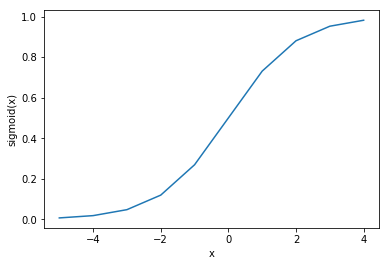

```python
import numpy as np
x = range(-5, 5)

def sigmoid(inputs):
    return [1 / float(1 + np.exp(- x)) for x in inputs]

y_sigmoid = sigmoid(x)
line_graph(x, y_sigmoid, "x", "sigmoid(x)")
```

- Hyperbolic tangent

$$\phi(x) = \tanh(x)$$

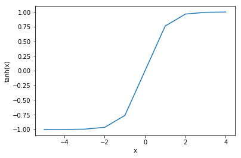

```python
def tanh(inputs):
    values = [ np.tanh(x) for x in inputs]
    return values

y_tanh = tanh(x)
line_graph(x, y_tanh, "x", "tanh(x)")
```

- Rectified Linear Unit fuction (ReLU)

$$\phi(x) = x I_{x \ge 0}$$

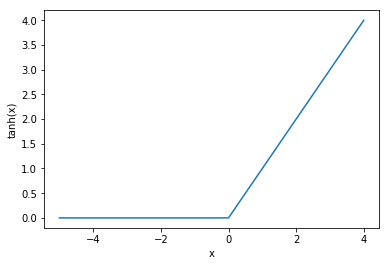

```python
def ReLU(inputs):
    values = [x if x>0 else 0 for x in inputs]
    return values

y_relu = ReLU(x)
line_graph(x, y_relu, "x", "tanh(x)")
```

### Activation functions for the output layer

- Sigmoid

$$\phi(x) = \frac{1}{1 + \exp(-x)}$$

- Softmax

- Linear

$$\phi(x) = x$$

```python
def softmax(inputs):
    exp_inputs = np.exp(inputs)
    out = np.divide (exp_inputs, exp_inputs.sum())
    return out

softmax([1, 0.5, 2])
```

```
array([ 0.2312239 ,  0.14024438,  0.62853172])
```

### Error functions

- Mean Squared Error (MSE), for regression

$$ E = \frac{1}{n}\sum_{i=1}^n (y_i - \hat{y}_i)^2$$

```python
def mse(y, yhat):
    y = np.array(y)
    yhat = np.array(yhat)
    out = np.sum((y-yhat)**2)/len(y)
    return out

y=[1,0,1,1]
yhat=[0.4,0.6,0.1,0.5]
round(mse(y, yhat),2)
```

```
0.44
```

- Cross-entropy, for classification

$$ E = - \frac{1}{n}\sum_{i=1}^n \left( y_i \log(\hat{p}_i) + (1- y_i) \log(1-\hat{p}_i) \right)$$

```python
def cross_entropy(y, p):
    y = np.array(y)
    p = np.array(p)
    out = - (np.dot(y, np.log(p)) + np.dot(1-y, np.log(1-p)))
    return out

y=[1,0,1,1]
p=[0.4,0.6,0.1,0.5]
print(round(cross_entropy(y, p),2))
```

```
4.83
```

Side note: you can make those graphs using the 'dot' language. For this, save this code in a *feedforward.txt* file

```
digraph G {
    rankdir=LR
    splines=line
    node [fixedsize=true, label=""];

    x1 -> h1;
    x2 -> h1;
    x1 -> h2;
    x2 -> h2;
    h2 -> y;
    h1 -> y;
}
```

and run in Terminal

`dot -Tpng -O feedforward.txt`

### Backpropagation

During **Backpropagation** we compute backwards (right to left) and update the weights to minimize the error.

[figure not shown]

### Gradient Descent

Generally, **gradient** of a function $E(x_1,...,x_n)$

$$\nabla_{(x_1,...,x_n)} E = \begin{pmatrix} \frac{\partial E}{\partial x_1} \\ ... \\ \frac{\partial E}{\partial x_n} \end{pmatrix}$$

is a vector in the direction of the fastest growth of a function. Since our aim is to minimize the error, we are interested to find $- \nabla E$: it indicates in which direction the function decreases the most.

It follows, that a good way to update the weights is

$$ W^{new} = W^{old} + \nabla_W (-E).$$

Anyhow, if the size of the step $\nabla_W (-E)$ is too small or too large, it may take too long to find the minimum or we may overshoot, respectively. To adjust, a **learning rate** $\alpha$ is introduced.

### Weights update

$$ W^{new} = W^{old} + \alpha \nabla_W (-E),$$

where $\alpha$ is the learning rate, i.e. the step size and $\nabla_W E$ denots the gradient of the error function with repect to the parameters $W$. This can be also written as

$$ W^{new}_{ij} = W^{old}_{ij} + \alpha \left( -\frac{\partial E}{\partial W_{ij}} \right).$$

It is not uncommon to use the notation $$\delta_{ij} = \frac{\partial y}{\partial W_{i,j}}.$$

Then $$\frac{\partial E}{\partial W_{ij}} = \frac{\partial E}{\partial y} \frac{\partial y}{\partial W_{ij}} = \delta_{ij} \frac{\partial E}{\partial y}.$$

Applying the chain rule

$$\delta_{ij} = \frac{\partial y}{\partial W_{ij}} = \sum_{k=1}^{n} \frac{\partial \Phi}{\partial h_k} \frac{\partial h_k}{\partial W_{ij}},$$

i.e. we need to sum over all paths between $W_{ij}$ and $y$.

### Useful derivatives

- Sigmoid

$$\sigma'(x) = \frac{\partial}{\partial x} \frac{1}{1 + \exp(-x)} = \frac{\exp(-x)}{(1 + \exp(-x))^2} = \sigma(x) \left(1- \sigma'(x) \right).$$

- Hyperbolic tangent

$$\tanh'(x) = 1 -\tanh^2(x).$$

- Rectified Linear Unit

$$\text{ReLU}'(x) = I_{x \ge 0}$$

### Calculations for perceptron

Now, when we understand the general workflow, let us construct the training algorithm for one perceptron with sigmoid activation function (performing logistic regression).

[figure not shown]

The goal is to minimize the error function, which is the mean point-wise error over $m$ training inputs

$$E = \frac{1}{m} \sum E_k,$$ $$E_k = - (y_i \ln(\hat{p_k}) + (1-y_k) \ln(1- \hat{p_k})).$$

The predicted probabilities are evaluated via the activation function $$\hat{p_k} = \sigma(x_k^T W + b).$$

Let us drop the index for now and perform computations for one observation

$$E = - (y \ln(\hat{p}) + (1-y) \ln(1- \hat{p})).$$

We need to find $\frac{\partial E}{\partial W_i}$ (here denote $W_{i1}$ as $W_i$ and consider $\frac{\partial E}{\partial b}$ be the particular case of $\frac{\partial E}{\partial W_i}$).

Beforehand, compute $$ \frac{\partial \hat{p}}{\partial W_i} = \frac{\partial}{\partial W_i}\sigma(x^T W + b) = \hat{p} (1-\hat{p}) x_i. $$

Then $$ \begin{aligned} \frac{\partial E}{\partial W_i} &= - \left(y \frac{\partial}{\partial W_i} \ln(\hat{p}) + (1-y) \frac{\partial} {\partial W_i} \ln(1- \hat{p}) \right) \\ &= - \left(y \frac{1}{\hat{p}} \frac{\partial \hat{p}}{\partial W_i} + (1-y) \frac{1}{1-\hat{p}} \frac{\partial (-\hat{p})} {\partial W_i} \right) = \text{(substitute from above)} \\ &= - (y - \hat{p}) x_i, \end{aligned} $$ and it follows, in particular, $$ \frac{\partial E}{\partial b} = - (y - \hat{p}). $$

#### Logistic regression training algorithm

- initialize randomly weights $W$ and bias $b$
- repeat until the error is small:
  - compute prediction $\hat{p}_i$ for each training input $x_i$,
  - update weights and bias.

### Perceptron implementation

```python
# useful functions
def sigmoid(x):
    return 1 / (1 + np.exp(-x))
```

```python
# Generate data:
# assume the line W1*x1+W*x2 separates the two regions: {y=1}, {y=0}
# b = 0

import numpy as np

#number of features
n_features = 2
n_labels = 1

#number of observations
m = 100

# generate features
Xsim = np.random.normal(0, 10, size=(m,n_features))

# set the values of true parameters
W_true = np.array([1.0, 3.0])
W_true.shape = (n_features,n_labels)

# fill the true lables
ysim = np.zeros(shape=(m,n_labels))
for i in range(m):
    if sigmoid(np.dot(Xsim[i,:], W_true))>0.5:
        ysim[i] = 1
```

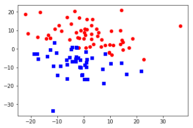

```python
# plot
Xred = Xsim[np.argwhere(ysim==1),:]
Xblue = Xsim[np.argwhere(ysim==0),:]
plt.plot(Xred[:,0,0], Xred[:,0,1], 'ro', Xblue[:,0,0], Xblue[:,0,1], 'bs')

# TO DO: increase the number of observations and observe the changes on the plot.
# How will the number of observations impact the predictions?
```

```python
# training hyperparameters
epochs = 100
learning_rate = 0.001

# initialize weights and bias
W = np.random.normal(0, 1, size=W_true.shape)
```

```python
def compute_probs(X, W):
    return sigmoid(np.dot(X, W))
```

```python
# train
for epoch in range(epochs):
    probs = compute_probs(Xsim, W)
    d_error = -(ysim - probs)
    W -= learning_rate * np.dot(Xsim.T, d_error)
    #b -= learning_rate * d_error

    # print every 10 epochs
    if (epoch + 1) % 10 == 0:
        print('epoch:{:4d},  W[0]: {:5f},  W[1]: {:5f}'.format(epoch + 1, float(W[0]), float(W[1])))
```

```
epoch:  10,  W[0]: 0.221072,  W[1]: 0.708476
epoch:  20,  W[0]: 0.247225,  W[1]: 0.786854
epoch:  30,  W[0]: 0.269193,  W[1]: 0.852349
epoch:  40,  W[0]: 0.288413,  W[1]: 0.909533
epoch:  50,  W[0]: 0.305673,  W[1]: 0.960826
epoch:  60,  W[0]: 0.321448,  W[1]: 1.007676
epoch:  70,  W[0]: 0.336050,  W[1]: 1.051029
epoch:  80,  W[0]: 0.349696,  W[1]: 1.091538
epoch:  90,  W[0]: 0.362544,  W[1]: 1.129676
epoch: 100,  W[0]: 0.374712,  W[1]: 1.165797
```

```python
# TO DO:
# Change the number of epochs and the learning rate several times and observe what happens to the output.
# Ideally we want to see, that the values converge to W_true.

# TO DO:
# adjust the code to account for bias

# TO DO*:
# implement perceptron as class
```

### Minibatch

Previously we assumed that weights are updated after each calculation of the output. The updates can be made every $N$ steps. Then $N$ is called the minibatch-size.

$$\delta = \frac{1}{N} \sum \delta_{ij}.$$

As the result, we will perform less computations to save time and average the noise out to improve convergence.

### Dropout

Dropout is a regularization method.

If one part of a neural network has very large weights, it will dominate the training proces. As a solution, some nodes are being switched off randomly with a give probability of the dropout for one training epoch.

### 7. Low level framework: Tensorflow

In a low level framework we need to operate on the linear algebra level.

```python
import tensorflow as tf

#check the version
tf.__version__
```

```
'1.1.0'
```

All data in Tensorflow is stored as a tensor, not integers/floats/strings. Tensor is a generalized version of those data types.

tf.constant() is a constant tensor:

```python
# 0-dimensional float32 tensor
tensor_int32_0dim = tf.constant(0.5)
print(tensor_int32_0dim)

# 1-dimensional int32 tensor
tensor_int32_1dim = tf.constant([123,456,789])
print(tensor_int32_1dim)

# 2-dimensional string tensor
tensor_int32_2dim = tf.constant([ ['s1','s2','s3'], ['s4','s5','s6'] ])
print(tensor_int32_2dim)
```

```
Tensor("Const:0", shape=(), dtype=float32)
Tensor("Const_1:0", shape=(3,), dtype=int32)
Tensor("Const_2:0", shape=(2, 3), dtype=string)
```

tf.Session() creates a session and session.run() runs the comutational graph.

tf.placeholder() is a tensor, which receivs the data from a dictionary feed_dict during execution time:

```python
output = None
x = tf.placeholder(tf.string)

with tf.Session() as sess:
    output = sess.run(x, feed_dict = {x: 's1'})
    print(output)
```

```
s1
```

### Mathematical operations in Tensorflow

tf.add()

tf.subtract()

tf.multiply()

tf.divide()

tf.cast(,tf.float64)

tf.Variable() is the variable, i.e. can be modified.

tf.global_variables_initializer() initializes all the variable tensors.

tf.truncated_normal()

tf.zeros()

tf.nn.softmax()

tf.reduce_sum()

tf.reduce_mean()

### Examples

```python
import tensorflow as tf

# multiplication
x1 = tf.placeholder("float")
x2 = tf.placeholder("float")
y = tf.add(x1, x2)

with tf.Session() as sess:
    print("%f should equal 3.0" % sess.run(y, feed_dict={x1: 1, x2: 2}))
    print("%f should equal 6.0" % sess.run(y, feed_dict={x1: 3, x2: 4}))

# TO DO: use 'multiply' to evaluate the product of x1 and x2 in Tensorflow
#y = None
#with tf.Session() as sess:
#    print("%f should equal 2.0" % sess.run(y, feed_dict={x1: 1, x2: 2}))
#    print("%f should equal 12.0" % sess.run(y, feed_dict={x1: 3, x2: 4}))
```

[output not shown]

### Logistic regression with Tensorflow

Let us generate labels in 2D being separated not ina linear way and test the performance of logistic regression on it.

```python
# generate the data

import numpy as np

#number of features
n_input = 2
n_classes = 1

#number of observations
m = 5000

# generate features
Xsim = np.random.normal(0, 10, size=(m,n_input))

# set the values of trrue parameters
W_true = np.array([1.0, 3.0])
#b_true = -1

# fill the true lables
ysim = np.zeros(shape=(m,n_classes))

s = np.dot(Xsim[1,:], W_true)
for i in range(m):
    if Xsim[i,0]**3/15 + Xsim[i,0]**2 -1 > Xsim[i,1]: # parabola y = x^2
        ysim[i] = 1
```

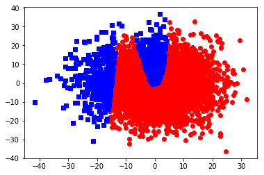

```python
# plot
import matplotlib.pyplot as plt
Xred = Xsim[np.argwhere(ysim==1),:]
Xblue = Xsim[np.argwhere(ysim==0),:]
plt.plot(Xred[:,0,0], Xred[:,0,1], 'ro', Xblue[:,0,0], Xblue[:,0,1], 'bs')
```

```python
# split X and y into train and test as 80% to 20%
train_portion = 0.8
train_m = round(m* train_portion)
print(train_m)
Xtrain = Xsim[0:train_m,]
Xtest = Xsim[train_m:,]
ytrain = ysim[0:train_m]
ytest = ysim[train_m:]

# check the shapes
print(Xtrain.shape)
print(Xtest.shape)
print(ytrain.shape)
print(ytest.shape)
```

```
4000
(4000, 2)
(1000, 2)
(4000, 1)
(1000, 1)
```

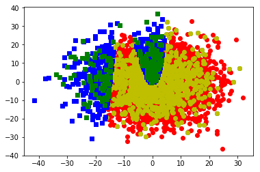

```python
Xred = Xtrain[np.argwhere(ytrain==1),:]
Xorange = Xtest[np.argwhere(ytest==1),:]
Xblue = Xtrain[np.argwhere(ytrain==0),:]
Xgreen = Xtest[np.argwhere(ytest==0),:]
plt.plot(Xred[:,0,0], Xred[:,0,1],  'ro')
plt.plot(Xorange[:,0,0], Xorange[:,0,1],  'go')
plt.plot(Xorange[:,0,0], Xorange[:,0,1],  'yo')
plt.plot(Xblue[:,0,0], Xblue[:,0,1],  'bs')
plt.plot(Xgreen[:,0,0], Xgreen[:,0,1],  'gs')
```

```python
import tensorflow as tf
```

```python
def lin_pred(X, W, b):
    lin = tf.matmul(X, W) + b
    return lin
```

```python
X = tf.placeholder("float", [None, n_input])
y = tf.placeholder("float", [None, n_classes])
```

```python
W = tf.Variable(tf.random_normal([n_input, n_classes], mean=0.0, stddev=0.05))
b = tf.Variable([0.])
```

```python
y_lin_pred = lin_pred(X, W, b)
p = tf.sigmoid(y_lin_pred)   # for prediction
```

```python
cross_entropy = tf.nn.sigmoid_cross_entropy_with_logits(logits=y_lin_pred, labels=y)
loss = tf.reduce_mean(cross_entropy)
```

```python
train_step = tf.train.GradientDescentOptimizer(0.01).minimize(loss)
delta = tf.abs((y - p))
prediction = tf.round(p)
correct_prediction = tf.cast(tf.equal(prediction, y), dtype=tf.float32)
accuracy = tf.reduce_mean(tf.cast(correct_prediction, tf.float32))
```

```python
# Train
init = tf.global_variables_initializer()
```

```python
epochs = 500
loss_trace = []
accuracy_train = []
accuracy_test = []
```

```python
# set a path where to store the model
model_path = "./saved_model/model.ckpt"

# 'Saver' to save and restore all the variables
saver = tf.train.Saver()
```

```python
with tf.Session() as sess:
    sess.run(init)

    print('Training...')
    for i in range(epochs):
        fd_train = {X: Xtrain, y: ytrain}
        train_step.run(fd_train)

        fd_test = {X: Xtest, y: ytest}

        if i % 100 == 0:
            loss_step = loss.eval(fd_train)
            train_accuracy = accuracy.eval(fd_train)
            test_accuracy = accuracy.eval(fd_test)
            loss_trace.append(loss_step)
            accuracy_train.append(train_accuracy)
            accuracy_test.append(test_accuracy)
            print('  Epoch, Loss, Accurary = %6d: %8.3f,%8.3f' % (i, loss_step, train_accuracy))


    # Test trained model
    fd_test = {X: Xtest, y: ytest}
    print('Accuracy = %10.4f' % accuracy.eval(fd_test))

     # Save model weights to disk
    save_path = saver.save(sess, model_path)
    print("Model saved in file: %s" % save_path)
```

```
Training...
  Epoch, Loss, Accurary =      0:    0.614,   0.681
  Epoch, Loss, Accurary =    100:    0.534,   0.750
  Epoch, Loss, Accurary =    200:    0.484,   0.777
  Epoch, Loss, Accurary =    300:    0.450,   0.791
  Epoch, Loss, Accurary =    400:    0.426,   0.800
Accuracy =     0.8190
Model saved in file: ./saved_model/model.ckpt
```

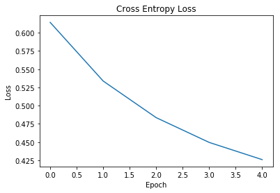

```python
# Visualization of the results
# loss function
plt.plot(loss_trace)
plt.title('Cross Entropy Loss')
plt.xlabel('Epoch')
plt.ylabel('Loss')
plt.show()
```

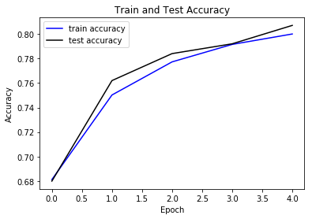

```python
# accuracy
plt.plot(accuracy_train, 'b-', label='train accuracy')
plt.plot(accuracy_test, 'k-', label='test accuracy')
plt.xlabel('Epoch')
plt.ylabel('Accuracy')
plt.title('Train and Test Accuracy')
plt.legend(loc='best')
plt.show()
```

### Save and restore TF models

After we trained a model, we can save it with

`saver = tf.train.Saver()`

`saver.save(sess, model_path)`

and restore with

`saver.restore(sess, "/tmp/model.ckpt")`.

Let us restore the model from above and continue training:

```python
epochs = 50
```

```python
print("Restoring model...")
with tf.Session() as sess:
    # Initialize variables
    sess.run(init)

    # Restore model weights from previously saved model
    load_path = saver.restore(sess, model_path)
    print("Model restored from file: %s" % save_path)

    print("Continue training")
    for i in range(epochs):
        fd_train = {X: Xtrain, y: ytrain}
        train_step.run(fd_train)

        fd_test = {X: Xtest, y: ytest}

        if i % 10 == 0:
            loss_step = loss.eval(fd_train)
            train_accuracy = accuracy.eval(fd_train)
            test_accuracy = accuracy.eval(fd_test)
            loss_trace.append(loss_step)
            accuracy_train.append(train_accuracy)
            accuracy_test.append(test_accuracy)
            print('  Epoch, Loss, Accurary = %6d: %8.3f,%8.3f' % (i, loss_step, train_accuracy))


    # Test trained model
    fd_test = {X: Xtest, y: ytest}
    print('Accuracy = %10.4f' % accuracy.eval(fd_test))
```

```
Restoring model...
INFO:tensorflow:Restoring parameters from ./saved_model/model.ckpt
Model restored from file: ./saved_model/model.ckpt
Continue training
  Epoch, Loss, Accurary =      0:    0.409,   0.804
  Epoch, Loss, Accurary =     10:    0.408,   0.805
  Epoch, Loss, Accurary =     20:    0.406,   0.806
  Epoch, Loss, Accurary =     30:    0.405,   0.807
  Epoch, Loss, Accurary =     40:    0.404,   0.808
Accuracy =     0.8210
```

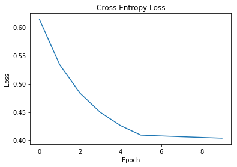

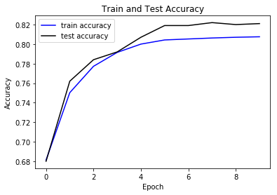

```python
# Visualization of the results
# loss function
plt.plot(loss_trace)
plt.title('Cross Entropy Loss')
plt.xlabel('Epoch')
plt.ylabel('Loss')
plt.show()

# accuracy
plt.plot(accuracy_train, 'b-', label='train accuracy')
plt.plot(accuracy_test, 'k-', label='test accuracy')
plt.xlabel('Epoch')
plt.ylabel('Accuracy')
plt.title('Train and Test Accuracy')
plt.legend(loc='best')
plt.show()
```

Conclusion: accuracy does not improve with the increasing number oh epochs. This means that the logistic regression model can not do better on the nonlinear problem. That is why we need deeper nets.

Our implementations above did not include batching and dropouts for simplicity.

To build a deeper network we need to stack hidden layers together. By stacking several fully connected layers we will obtain a **multilayer perceptron** (MLP). As a rule of thumb, the number of nodes in the hidden layers should be larger than the number of features, while the number of layers greated than two might not help much.

### 8. A remark on Keras

Keras is high level framework and allows to simply define the layers. Keras wraps TensorFlow and uses it as execution backened.

```python
from keras.models import Sequential
model = Sequential()
```

```python
import numpy as np
from keras.models import Sequential
from keras.layers.core import Dense, Activation, Dropout

# X has shape (num_rows, num_cols), where the training data are stored
# as row vectors
X = np.array([[0, 0], [0, 1], [1, 0], [1, 1]], dtype=np.float32)

# y must have an output vector for each input vector
y = np.array([[0], [0], [0], [1]], dtype=np.float32)

# Create the Sequential model
model = Sequential()

# 1st Layer - Add an input layer of 32 nodes with the same input shape as
# the training samples in X
# creates 32 nodes which each expect to receive 2-element vectors as inputs.
model.add(Dense(32, input_dim=X.shape[1]))

# Add a softmax activation layer
model.add(Activation('softmax'))

# 2nd Layer - Add a fully connected output layer
model.add(Dense(1))

# Add a sigmoid activation layer
model.add(Activation('sigmoid'))
```

```python
model.compile(loss="categorical_crossentropy", optimizer="adam", metrics = ["accuracy"])
```

The resulting model architecture can be viewed with the following command:

```python
model.summary()
```

```
_________________________________________________________________
Layer (type)                 Output Shape              Param #
=================================================================
dense_1 (Dense)              (None, 32)                96
_________________________________________________________________
activation_1 (Activation)    (None, 32)                0
_________________________________________________________________
dense_2 (Dense)              (None, 1)                 33
_________________________________________________________________
activation_2 (Activation)    (None, 1)                 0
=================================================================
Total params: 129
Trainable params: 129
Non-trainable params: 0
_________________________________________________________________
```

The model is trained with the fit() method, through the following command that specifies the number of training epochs and the message level (how much information we want displayed on the screen during training).

```python
#model.fit(X, y, epochs=1000, verbose=0)
#model.evaluate()
```

In a nutshell, that's all of it:

```python
import numpy as np
from keras.models import Sequential
from keras.layers.core import Dense, Activation, Dropout
```

```python
n1 = 3
n2 = 3
dropout_prop = 0.2
model = Sequential()
model.add(Dense(n1, input_dim=n_input))
model.add(Activation('sigmoid'))
model.add(Dropout(dropout_prop))
model.add(Dense(n2))
model.add(Activation('sigmoid'))
model.add(Dense(n_classes))
model.add(Activation('sigmoid'))
model.compile(loss = 'binary_crossentropy', optimizer='adam', metrics=['accuracy'])
model.summary()
```

```
_________________________________________________________________
Layer (type)                 Output Shape              Param #
=================================================================
dense_4 (Dense)              (None, 3)                 9
_________________________________________________________________
activation_4 (Activation)    (None, 3)                 0
_________________________________________________________________
dropout_2 (Dropout)          (None, 3)                 0
_________________________________________________________________
dense_5 (Dense)              (None, 3)                 12
_________________________________________________________________
activation_5 (Activation)    (None, 3)                 0
_________________________________________________________________
dense_6 (Dense)              (None, 1)                 4
_________________________________________________________________
activation_6 (Activation)    (None, 1)                 0
=================================================================
Total params: 25
Trainable params: 25
Non-trainable params: 0
_________________________________________________________________
```

```python
# create model
model = Sequential()
model.add(Dense(n1, input_dim=n_features, activation='relu'))
model.add(Dense(n2, activation='relu'))
model.add(Dense(n_classes, activation='sigmoid'))
```

```python
# Compile model
model.compile(loss='binary_crossentropy', optimizer='adam', metrics=['accuracy'])
```

```python
# Fit the model
model.fit(Xtrain, ytrain, epochs=50, batch_size=10)
```

```
<keras.callbacks.History at 0x11caa5278>
```

```python
# evaluate the model
scores = model.evaluate(Xtest, ytest)
print("\n%s: %.2f%%" % (model.metrics_names[1], scores[1]*100))
```

```
acc: 81.40%
```

Choices to make for the architechture and the values of hyperparameters:

```
* number of layers
* sizes of the layers
* number of epochs
* batch size
* Activation function (sigmoid, relu, tanh, softmax)
* Loss function (binary_crossentropy, categorical_crossentropy, mean_squared_error)
* Optimizer (rmsprop, adam, ada)
* Dropout probability
```

## Part 3: Projects

**Text** is what we use to communicate. It documents how we talk and write. News as text is available and is relatively easy to scrap. Video and audio news can be transformed to text with the help of APIs.

### 10. Speech to text

Speech Recognition using **Google Speech API**

We will perform a live demo, but not do this execrcise all together during the workshop, since it requires additional installations. Here is how they can be done:

Installations (on Mac)

`git clone http://people.csail.mit.edu/hubert/git/pyaudio.git`

`cd pyaudio`

`brew install portaudio`

`pip install pyAudio`

`pip install SpeechRecognition`

Save the following code in a file speech2text.py and run in Termial with

`python speech2text.py`

```
#speech2text.py
# Requires PyAudio and PySpeech.
import speech_recognition as sr

# Record Audio
r = sr.Recognizer()
with sr.Microphone() as source:
    print("Say something!")
    audio = r.listen(source)

# Speech recognition using Google Speech Recognition
try:
    # for testing purposes, we're just using the default API key
    # to use another API key, use `r.recognize_google(audio, key="GOOGLE_SPEECH_RECOGNITION_API_KEY")`
    # instead of `r.recognize_google(audio)`
    print("You said: " + r.recognize_google(audio))
except sr.UnknownValueError:
    print("Google Speech Recognition could not understand audio")
except sr.RequestError as e:
    print("Could not request results from Google Speech Recognition service; {0}".format(e))
```

The result should look as follows:

[figure not shown]

### 11. Information retrieval (with spaCy) </span>

As discussed before, we can represent each text as a vector of a fixed length and evaluate the proximity of two texts as proximity of vectors. The [SpaCy](https://spacy.io/) library can help us do it neatly.

Given a piece of news and a set of emails, we will extract the most relevant emails with respect to the news based on the **similarity** of texts. Similarity is determined by comparing word vectors or "word embeddings", multi-dimensional meaning representations of a word. Word vectors can be generated using an algorithm like word2vec. Documentations can be found [here](https://spacy.io/usage/vectors-similarity).

```python
# Activate the AMLD environment:
# source activate amld
#Install:
# conda install spacy
# python3 -m spacy download en
```

```python
import spacy

nlp = spacy.load('en')

def similarity(text1, text2):
    doc1 = nlp(text1)
    doc2 = nlp(text2)
    sim = round(doc1.similarity(doc2),2)
    return sim
```

```python
# a trivial example
text_name_1 = 'spacy/easy_text1.txt'
text_name_2 = 'spacy/easy_text1.txt'
text1 = open(text_name_1).read()
text2 = open(text_name_2).read()
sim = similarity(text1, text2)
print('Similarity of documents = ' +  str(sim))
```

```
Similarity of documents = 1.0
```

```python
# read in the news text
text_name = 'data/news1.txt'
text_news = open(text_name).read()
print(text_news)
```

```
imply that Hillary has a life- threatening condition called sinus thrombosis, helped create ISIS, and was responsible for the death of Americans in Benghazi
```

```python
# read emails
import json

def load_json_data(path_to_file):
    lol = pd.read_json(path_to_file,encoding='ascii')
    data_DF = lol.T
    data_DF['from'] = data_DF['from'].str.lower()
    data_DF['body'] = data_DF['body'].apply(lambda x: " ".join(str(x).split()))
    #print(data_DF['body'])
    return data_DF
```

```python
import pandas as pd
emails_pd = load_json_data('data/fulldatastuff.json')
```

```python
emails_pd.head()
```

|  | body | date | from | from_name | subject | to |
| --- | --- | --- | --- | --- | --- | --- |
| 0 | How many more states can we get to follow Conn... | 2016-05-17T19:51:22-07:00 | gardem@dnc.org | Maureen Garde | Re: CT To Automatically Register 400,000 Voters | [["Davis, Marilyn", DavisM@dnc.org]] |
| 1 | She maxed out to us earlier this year total un... | 2016-05-04T06:58:23-07:00 | shapiroa@dnc.org | "Shapiro, Alexandra" | What about asking Toni Bush to host? | [["Kaplan, Jordan", KaplanJ@dnc.org]] |
| 10 | nan | 2016-05-04T16:49:31-04:00 | postmaster@my.democrats.org | Contribution | Contribution: Finance - Tristate 2016 / Judith... | [[,, allenz@dnc.org], [,, parrishd@dnc.org], [... |
| 100 | Jordan KaplanNational Finance DirectorDemocrat... | 2016-04-25T14:54:17-04:00 | kaplanj@dnc.org | Jordan Kaplan | Re: Paris reception | [["Rauscher, Rachel", RauscherR@dnc.org]] |
| 1000 | nan | 2016-05-04T05:47:44-06:00 | illinoisplaybook@politico.com | Natasha Korecki | POLITICO Illinois Playbook, presented by Nucle... | [] |

```python
emails = emails_pd['body'].tolist()
print(emails[0])
emails = emails[0:100]
print(len(emails))
```

```
How many more states can we get to follow Connecticut? Way to go!
100
```

```python
# for a given news piece iterate through all emails and find ntop relevant ones
from collections import defaultdict
from heapq import nlargest

similarities = defaultdict(int)

def similar_emails(text_news, emails, ntop=1):
    for i in range(len(emails)):
        email = emails[i]
        similarities[i] = similarity(text_news, email)
    similarities_index = nlargest(ntop, similarities, key=similarities.get)
    return [emails[similarities_index[i]] for i in range(ntop)]

relevant_emails = similar_emails(text_news, emails, ntop=1)
print(relevant_emails[0][0:1000])
```

```
IN CASE YOU MISSED ITThe Only Time Donald Trump Undersells: Tax TimeABC NewsBy Brian RossMay 16, 2016http://abcnews.go.com/Politics/time-donald-trump-undersells-tax-time/story?id=39133709The Trump National Golf Club in Westchester County, New York, with its lovingly-manicured golf course, gently win…
```

### Documentation:

https://spacy.io/

### 12. Text summarization (with NLTK)

Another great library to work with texts is [NLTK](http://www.nltk.org/), which stands for Natural Language Toolkit. We have now extracted a large set of news on a given topic and would like to extract the most informative parts: out of each text we would like to exatract the most informative sentence. This type of summarization of texts is called **extractive**.

Take a look at this video: [Hillary Clinton's concession speech](https://www.vox.com/2016/11/9/13570328/hillary-clinton-concession-speech-full-transcript-2016-presidential-election). The webpage already provides the full transcript.

We will approach this task as follows:

```python
# import text

text=open('data/trainhillary.txt').read().lower().replace('\xa0',' ')
print('corpus length:', len(text))
text[0:300]
```

```
corpus length: 6390
```

```
'thank you. thank you all very much. thank you so much.\n\nvery rowdy group. thank you, my friends. thank you. thank you. thank you so very much for being here. i love you all, too.\n\nlast night i congratulated donald trump and offered to work with him on behalf of our country.\n\ni hope that he wi…
```

```python
import nltk
from nltk.corpus import stopwords
from collections import defaultdict
stopWords = set(stopwords.words("english"))
```

```python
sentences = nltk.sent_tokenize(text)
len(sentences)
sentences[0:10]
```

```
['thank you.',
 'thank you all very much.',
 'thank you so much.',
 'very rowdy group.',
 'thank you, my friends.',
 'thank you.',
 'thank you.',
 'thank you so very much for being here.',
 'i love you all, too.',
 'last night i congratulated donald trump and offered to work with him on behalf of our country.']
```

```python
word_sent = [nltk.word_tokenize(s.lower()) for s in sentences]
```

```python
word_sent[0:5]
```

```
[['thank', 'you', '.'],
 ['thank', 'you', 'all', 'very', 'much', '.'],
 ['thank', 'you', 'so', 'much', '.'],
 ['very', 'rowdy', 'group', '.'],
 ['thank', 'you', ',', 'my', 'friends', '.']]
```

```python
#compute frequencies
freq = defaultdict(int)
for sentence in word_sent:
    for word in sentence:
        if word not in stopWords:
            freq[word] +=1
len(freq)
```

```
353
```

```python
m = float(max(freq.values()))
m
```

```
77.0
```

```python
for word in freq.keys():
    freq[word] = freq[word]/m
```

```python
min_cut=0.2
max_cut=0.8
freq_new = defaultdict(int)
for word in freq.keys():
    if not freq[word] > max_cut or freq[word] < min_cut:
        freq_new[word] = freq[word]
freq = freq_new
del freq_new
```

```python
len(freq)
```

```
351
```

```python
ranking = defaultdict(int)
for i, sentence in enumerate(word_sent):
        for word in sentence:
            if word in freq:
                ranking[i] +=freq[word]
```

```python
from heapq import nlargest
sentences_index = nlargest(1, ranking, key=ranking.get)
print(sentences_index)
sentences[sentences_index[0]]
```

```
[35]
```

```
'we’ve spent a year and a half bringing together millions of people from every corner of our country to say with one voice that we believe that the american dream is big enough for everyone—for people of all races, and religions, for men and women, for immigrants, for lgbt people, and people with di…
```

```python
## All of it in one function
from heapq import nlargest
import nltk
from nltk.corpus import stopwords
from collections import defaultdict

stopWords = set(stopwords.words("english"))

def summarize_text(text, stopWords, min_cut, max_cut, ntop=1):

    sentences = nltk.sent_tokenize(text)

    word_sent = [nltk.word_tokenize(s.lower()) for s in sentences]

    # compute frequencies
    freq = defaultdict(int)
    for sentence in word_sent:
        for word in sentence:
            if word not in stopWords:
                freq[word] +=1

    # normilize frequencies
    m = float(max(freq.values()))
    for word in freq.keys():
        freq[word] = freq[word]/m

    # cut off too frequent or too rare words
    freq_new = defaultdict(int)
    for word in freq.keys():
        if not freq[word] >= max_cut or freq[word] <= min_cut:
            freq_new[word] = freq[word]
    freq = freq_new
    del freq_new

    # rank sentences
    ranking = defaultdict(int)
    for i, sentence in enumerate(word_sent):
        for word in sentence:
            if word in freq:
                ranking[i] +=freq[word]

    sentences_index = nlargest(ntop, ranking, key=ranking.get)
    summary = [sentences[sentences_index[ind]] for ind in range(len(sentences_index))]
    return summary
```

```python
min_cut = 0.2
max_cut = 0.8
ntop = 1
summary = summarize_text(text, stopWords, min_cut, max_cut, ntop)
print('SUMMARIZING SENTENCE : \n' + str(summary[0]))
```

```
SUMMARIZING SENTENCE :
we’ve spent a year and a half bringing together millions of people from every corner of our country to say with one voice that we believe that the american dream is big enough for everyone—for people of all races, and religions, for men and women, for immigrants, for lgbt people, and people with dis…
```

### 13. Fake news challenge

The challenge: http://www.fakenewschallenge.org/

Data: https://github.com/FakeNewsChallenge/fnc-1

We will use the 3rd winning project: https://github.com/uclmr/fakenewschallenge

A striking fact: MLP performs nearly as good as more complex models.

[figure not shown]

(Source: https://medium.com/@andre134679/team-athene-on-the-fake-news-challenge-28a5cf5e017b)

Architechture:

[figure not shown]

(Source: https://github.com/uclmr/fakenewschallenge)

Use "train_amld" in the final/fakenewschallenge_master

```python
# TO DO:
# try out different architechtures than MLP to improve accuracy
```